# Лабораторная работа №3

Операционные системы

Бызова Мария Олеговна, НПИбд-01-23.

Российский университет дружбы народов, Москва, Россия

21 февраля 2024

## Цель работы

Целью данной лабораторной работы является научиться оформлять отчёты с помощью легковесного языка разметки Markdown.

## Задание

1. Сделайте отчёт по предыдущей лабораторной работе в формате Markdown.
2. В качестве отчёта предоставляются отчёты в 3 форматах: pdf, docx и md (в архиве, поскольку он должен содержать скриншоты, Makefile и т.д.)

## Теоретическое введение

Markdown — облегчённый язык разметки, созданный с целью обозначения форматирования в простом тексте, с максимальным сохранением его читаемости человеком, и пригодный для машинного преобразования в языки для продвинутых публикаций.

## Выполнение лабораторной работы

Перехожу в каталог, в котором находится шаблон для отчёта по лабораторной работе с помощью утилиты cd (рис. 1).

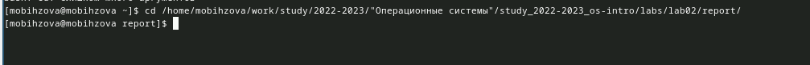

Перемещение между директориями

## Выполнение лабораторной работы

Открываю файл report.md с помощью текствого редактора Emacs (рис. 2).

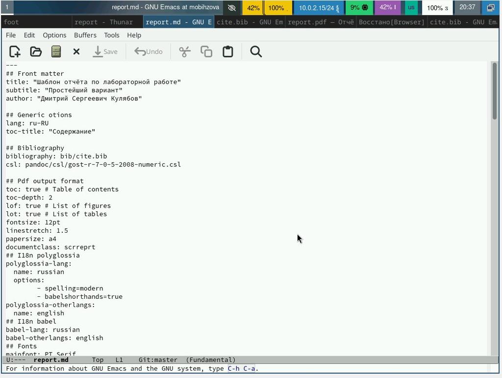

Открытие файла шаблона

## Выполнение лабораторной работы

Приступаю к заполнению отчета по лабораторной работе №2, подробно описывая все выполненные в ходе работы действия (рис. 3).

[figure not shown]

Редактирование файла

## Выполнение лабораторной работы

В файле cite.bib c помощью текстового редактора Emacs изменяю список библиографии, вставив интернет-ресурс, который я использовала (рис. 4).

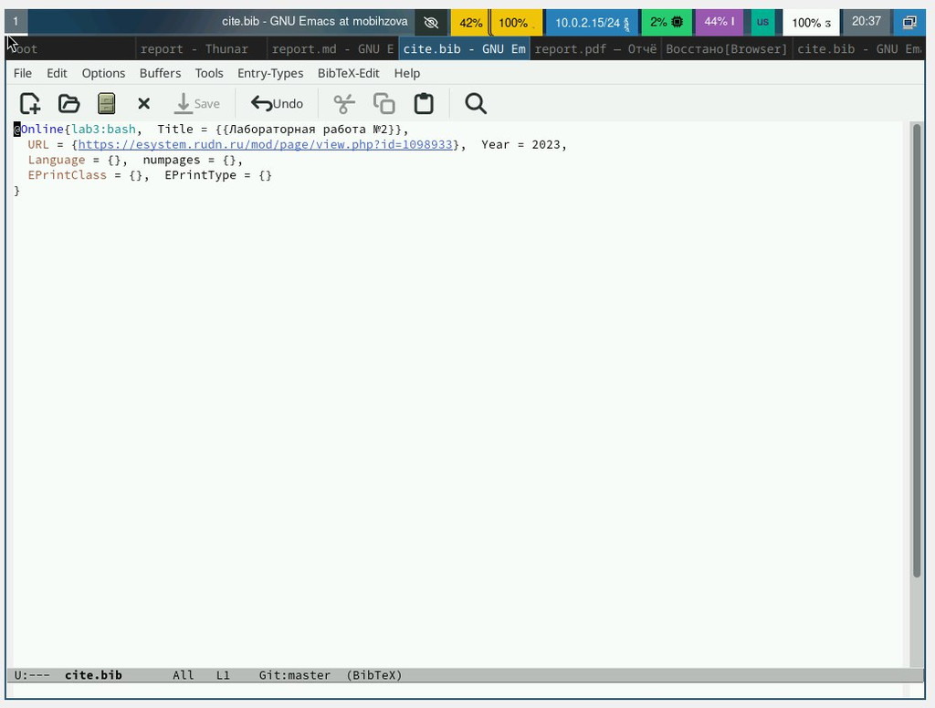

Редактирование файла

## Выполнение лабораторной работы

После изменения шаблона в соответствии с языком разметки Markdown, я выполняю компиляцию из формата md в формы docx и pdf (рис. 5).

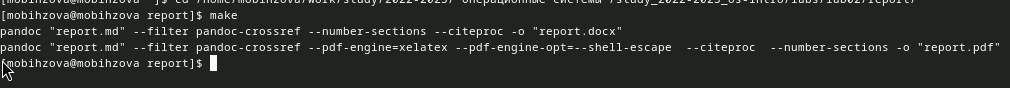

Компиляций отчета

## Выполнение лабораторной работы

При помощи утилиты ls убедимся в корректности компиляции отчёта. Все необходимые файлы созданы успешно (рис. 6).

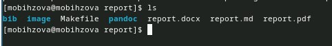

Каталог отчёта

## Выводы

В ходе выполнения данной лабораторной работы я научилась оформлять отчёты с помощью легковесного языка разметки Markdown.